# Supervised Classification of the Camp Fire 2018 with Random Forest

## Classification based on Remote Sensing Imagery in Python 2.7

This python script shows the workflow of how to implement a supervised classification based on remote sensing data. It consists of certain preprocessing steps including a cloud mask, the classification based on random forest and postprocessing steps. The code is the result of an university assignment on which I worked together with [Laura](https://github.com/lanbra).

This project aims to analyze the extent of the burned area following the Camp Fire 2018 in Paradise. To execute this task, two Landsat 8 scenes were compared, a prefire and a postfire scene.

**Note:** This script for processing raster data is built on the classic modules gdal, numpy and matplotlib. Without doubt, there is room from improvement, e.g. using rasterio, especially for plotting. Also, being new to machine learning, it has to be noted that this is a very simple application in which some methodological approaches (e.g. the resampling strategy) probably can be questioned. As it is known from Random Forest models, also this application most likely is suffering from overfitting.

**Modules and dependencies:**

- Python 2.7.17
- gdal 3.0.2
- os
- glob2 0.7
- numpy 1.15.1
- re
- matplotlib 2.2.4
- scikit-learn 0.20.0
- imbalanced-learn 0.4.2
- scipy 1.2.3

**Data download and preparation:**

- Download of the Landsat 8 scenes from the [USGS Earth Explorer](https://earthexplorer.usgs.gov/): 16.10. (Prefire) and 10.12.2018 (Postfire)
- Cropping the extent of both scenes to the area of interest
- Renaming the files following the pattern "LC08_Prefire_Paradise_B*.tif" respectively "LC08_Postfire_Paradise_B*.tif"
- Collecting of training data in the Postfire scene
- 8 classes: bare ground, masked cloud, water, shadow, vegetation, agriculture, sealed surfaces, burned area

**Links and tutorials:**

- [Scikit-learn (Random Forest Classifier)](https://scikit-learn.org/stable/modules/generated/sklearn.ensemble.RandomForestClassifier.html)
- [Classification tutorial by Chris Holden](https://ceholden.github.io/open-geo-tutorial/python/chapter_5_classification.html)
- [Quality Assessment Layer of Landsat 8](https://www.usgs.gov/land-resources/nli/landsat/landsat-collection-1-level-1-quality-assessment-band?qt-science_support_page_related_con=0#qt-science_support_page_related_con)

#### Import Packages

```python
from osgeo import gdal
import os
import glob
import numpy as np
import re
import matplotlib.pyplot as plt

from sklearn.ensemble import RandomForestClassifier
from sklearn.impute import SimpleImputer
from sklearn.model_selection import train_test_split
from sklearn.metrics import (accuracy_score, confusion_matrix, classification_report)

from imblearn.under_sampling import RandomUnderSampler
from imblearn.over_sampling import SMOTE

from scipy.ndimage.filters import generic_filter
from scipy.stats import mode
```

#### Function Definitions

```python
def read_raster (path):
    '''
    Reads tif-files as numpy array

    Parameter: absolute path to tif-file
    Returns: array, number of columns, number of rows, NoData value, geotransform, projection
    '''
    myrast = gdal.Open(path)
    NCOLS = myrast.RasterXSize
    NROWS = myrast.RasterYSize
    geotransform = myrast.GetGeoTransform()
    wkt_projection = myrast.GetProjection()
    mybandDSM = myrast.GetRasterBand(1)
    NoData = mybandDSM.GetNoDataValue()
    array_out = mybandDSM.ReadAsArray()

    return array_out, NCOLS, NROWS, NoData, geotransform, wkt_projection

def write_raster (array, geoTransform, projection, filename):
    '''
    Saves numpy array to tif-file

    Parameter: array, geotransform, projection, filename (absolute path)
    '''
    NCOLS = array.shape[1]
    NROWS = array.shape[0]

    driver = gdal.GetDriverByName("GTiff")
    dataset = driver.Create(filename, NCOLS, NROWS, 1, gdal.GDT_Float64 )
    dataset.SetGeoTransform(geoTransform)
    dataset.SetProjection(projection)
    dataset.GetRasterBand(1).WriteArray(array)
    dataset.FlushCache()

    #return dataset, dataset.GetRasterBand(1)

def create_cloudmask (cloud_mask):
    '''
    Transforms the quality assessment layer of Landsat 8 to binary array (1 and NaN)
    This layer contains information on the quality / corruption of the single pixels of the respective scene
    Pixels impacted by atmospheric interferences, such as clouds, snow and ice, should be masked out (set to NaN)
    Only valid pixels should be used (set to 1 in cloudmask)

    Parameter: array
    Returns: array (binary)
    '''
    cloud = [2800,2804,2808,2812,6896,6900,6904,6908]
    cloud_confidence_high = [2800,2804,2808,2812,6896,6900,6904,6908]
    cloud_shadow_high = [2976,2980,2984,2988,3008,3012,3016,3020,7072,7076,7080,7084,7104,7108,7112,7116]
    snow_ice_high = [3744,3748,3752,3756,3776,3780,3784,3788,7840,7844,7848,7852,7872,7876,7880,7884]

    #list with all values indicating pixels that should be masked
    masked_values = cloud + cloud_confidence_high + snow_ice_high + cloud_shadow_high

    #binary cloudmask
    for i in masked_values:
        cloud_mask[cloud_mask == i]=0
    cloud_mask[cloud_mask != 0]= 1 #valid pixels
    cloud_mask[cloud_mask == 0]= np.nan #invalid pixels

    return cloud_mask

def apply_cloudmask (cloud_mask, raster):
    '''
    Application of the cloudmask to the raster files
    By multiplying the cloudmask with the raster arrays valid pixel remain unchanged (multiplied with 1) whereas invalix pixel will be set to NaN

    Parameter: binary cloudmask array, raster (array) to be masked
    '''
    raster [: ,:]*=cloud_mask

    return raster

def normalization (band1, band2):
    '''
    calculation of NDVI and NBR indices

    Parameter: band1, band2
    Returns: calculated index as array
    '''
    result = (band1-band2)/(band1+band2)

    return result

def sort_list (list):
    '''
    Sorts the list with paths to bands (.tif): prefire b1-b12,nbr,ndvi, postfire b1-b12, nbr,ndvi

    Parameter: list
    Returns: list (sorted)
    '''
    convert = lambda text: int(text) if text.isdigit() else text
    alphanum_key = lambda key: [ convert(c) for c in re.split("([0-9]+)", key) ]
    list_sorted = sorted(list, key = alphanum_key)

    #"postfire" alphabetically sorted before "prefire"
    #"postfire" bands will be moved after "prefire" bands
    list_post = list_sorted[0:13] #temporarily saving postfire paths (first 13 items)
    del list_sorted[0:13] #deleting postfire paths
    list_sorted+=list_post #adding postfire paths againg

    return list_sorted

def redefine_nodata (array):
    '''
    NaN values will be set to -999999
    Background: randomforest classifier cannot handle NaN values
    SimpleImputer can identify NaN values and assign (user defined) new values

    Parameter: array
    Returns: array
    '''
    imputer = SimpleImputer(missing_values=np.nan, strategy='constant', fill_value=-999999)
    imputer = imputer.fit(array)
    array_redefined = imputer.transform(array)

    return array_redefined

def print_class_count(classes):
    '''
    Prints total number and number of pixel per class

    Parameter: array (pixel with assigned classes)
    '''
    n_samples = (classes > 0).sum()
    print "There are {n} training pixel".format(n=n_samples)

    labels = np.unique(classes[classes > 0])
    class_min, class_max = int(labels.min()), int(labels.max())

    print "Number of pixel per class:"
    for i in range (class_min, class_max+1):
        count = len(classes[classes==i])
        print "Class {k}: {c}".format(k=i, c=count)

def get_class_count_list(classes):
    '''
    Creates list with number of pixel per class

    Parameter: array (pixel with assigned classes)
    Return: List
    '''
    list_counts = []
    labels = np.unique(classes[classes > 0])
    class_min, class_max = int(labels.min()), int(labels.max())
    for i in range (class_min, class_max+1):
        count = len(classes[classes==i])
        list_counts.append(count)

    return list_counts

def modal_filter(values):
    '''
    Function for calculating the modal filter in moving window
    Assigns the most frequent, surrounding pixel value to the central pixel
    The smoothing effect highlights trends of the pixel based classification; certain loss of information

    Parameter: array (pixel values in moving window)
    Returns: float (single pixel value = most frequent value in moving window)
    '''
    raster_mode = mode(values,axis=None,nan_policy ="omit")

    return raster_mode[0]

def color_stretch(image, index, minmax=(0, 10000)):
    '''
    Preparation RGB polling of three bands
    Normalized bands (value range between 0 and 1)

    Parameter: array (layerstack), index (bands as tupel), valuerange bands
    Returns: array (normalized bands)
    '''
    colors = image[:, :, index].astype(np.float64)

    max_val = minmax[1]
    min_val = minmax[0]

    # Enforce maximum and minimum values
    colors[colors[:, :, :] > max_val] = max_val
    colors[colors[:, :, :] < min_val] = min_val

    for b in range(colors.shape[2]):
        colors[:, :, b] = colors[:, :, b] * 1 / (max_val - min_val)

    return colors
```

#### Set Data Paths

```python
path_wd = os.getcwd()
path_data = path_wd + "/LC08_Paradise_Data/"
path_postfire_QA = path_wd + "/LC08_Paradise_Data/postfire_qa/LC08_Postfire_Paradise_Quality.tif"
path_training = path_wd + "/LC08_Paradise_Data/roi/paradise_trainingdata.tif"
path_output_tmp = path_wd + "/output_tmp/"
path_output_fin = path_wd + "/output_final/"
```

## Main Script

### Part I: Preprocessing

First, loading bands as numpy array.

```python
#saving the absolute paths of the bands in list
band_list = glob.glob(os.path.join(path_data, "*.tif"))
#reading all bands as array with filename into dictionary
array_dict = {}
for i in band_list:
    filename = i.split("/")[-1][:-4]
    (array, NCOLS, NROWS, NoData, GeoTransform, projection) = read_raster(i)
    #Key: Filename --- Value: Numpy Array
    array_dict[filename] = array
```

To improve the data aggregation, the [Normalized Difference Vegetation Index (NDVI)](http://www.un-spider.org/links-and-resources/data-sources/daotm/daotm-vegetation) and [Normalized Burn Ratio (NBR)](http://un-spider.org/advisory-support/recommended-practices/recommended-practice-burn-severity/in-detail/normalized-burn-ratio) are calculated for both scenes.

```python
#requiring the arrays needed from dictionary
prefire_band4 = array_dict.get("LC08_Prefire_Paradise_B4") #RED
prefire_band5 = array_dict.get("LC08_Prefire_Paradise_B5") #NIR
prefire_band7 = array_dict.get("LC08_Prefire_Paradise_B7") #SWIR
postfire_band4 = array_dict.get("LC08_Postfire_Paradise_B4") #RED
postfire_band5 = array_dict.get("LC08_Postfire_Paradise_B5") #NIR
postfire_band7 = array_dict.get("LC08_Postfire_Paradise_B7") #SWIR

#calculation of the NDVI
ndvi_prefire = normalization (prefire_band5, prefire_band4)
ndvi_postfire = normalization (postfire_band5, postfire_band4)
#calculation of the NBR
nbr_prefire = normalization (prefire_band5, prefire_band7)
nbr_postfire = normalization (postfire_band5, postfire_band7)

#adding the indices to dictionary for accumulated data basis
array_dict["LC08_Prefire_Paradise_NDVI"] = ndvi_prefire
array_dict["LC08_Postfire_Paradise_NDVI"] = ndvi_postfire
array_dict["LC08_Prefire_Paradise_NBR"] = nbr_prefire
array_dict["LC08_Postfire_Paradise_NBR"] = nbr_postfire
```

#### Applying the cloud mask

To a certain degree, the postfire scene is impacted by atmospheric intereferences. To not falsify the classification, the respective pixels in both the prefire and postfire scene will be set to NaN. To achieve this, the information provided by the quality assessment layer for the postfire scene ist used. Pixel impacted by cloud, cloud shadow, snow and ice will be masked (see Function Definition). Find more information on the QA layer [here](https://www.usgs.gov/land-resources/nli/landsat/landsat-collection-1-level-1-quality-assessment-band?qt-science_support_page_related_con=0#qt-science_support_page_related_con).

```python
#loading the quality assessment layer of the postfire scene
(postfire_QA, NCOLS, NROWS, NoData, GeoTransform, Projection) = read_raster(path_postfire_QA)
#creating the binary cloud mask
cloud_mask = create_cloudmask(postfire_QA)

#applying the cloud mask to all bands
masked_array_dict = {}
for key in array_dict:
    raster_to_be_masked = array_dict.get(key)
    raster_masked = apply_cloudmask(cloud_mask, raster_to_be_masked)

    #masked arrays with corresponding naming
    if "Prefire" in key:
        keyname = "LC08_Prefire_Paradise_masked" + key[21:] #+Band
    elif "Postfire" in key:
        keyname = "LC08_Postfire_Paradise_masked" + key[22:] #+Band

    #key: array - value: bandname
    masked_array_dict[keyname] = raster_masked
```

#### Comparison: Postfire Truecolor Composite without (left) and (with) applied cloud mask

[figure not shown]

Saving all masked array as tifs in folder with temporary output.

```python
for key in masked_array_dict:
    raster = masked_array_dict.get(key)
    filename = path_output_tmp + key + ".tif"
    raster_out = write_raster(raster,GeoTransform, projection,filename)
```

### Part II: Classification

This section starts by again loading the masked bands from output_tmp (Background: Originally, this script was split in two scripts). One could adapt the script by directly transfering the arrays (keys) of the "masked_array_dict" into a list which is required for the further step of creating a layerstack. However, by doing this, the desired order (numerical (B1 - B11) and temporal (first prefire then postfire scene)) of the arrays / bands could not be ensured. This is room for improvement.

```python
#reading all band paths of prefire and postfire scene to list
layer_list = glob.glob(os.path.join(path_output_tmp, "*.tif"))
#sorting of bandlist
layer_list = sort_list(layer_list)

name_list =[] #stores the band names
array_list = [] #stores the bands (as array)
for i in layer_list:
    filename = i.split("/")[-1][:-4]
    name_list.append(filename)
    #reading alls 26 bands as arrays
    (array, NCOLS, NROWS, NoData, GeoTransform, Projection) = read_raster(i)
    #NaN Values set to -999999 (randomforest classifier in scikit-learn cannot handle NoData values)
    array_redefined = redefine_nodata(array)
    array_list.append(array_redefined)
```

```python
print NCOLS, NROWS, "----- GeoTransform:", GeoTransform, "----- Projection", Projection
```

```
1346 1149 ----- GeoTransform: (601905.0, 30.0, 0.0, 4417455.0, 0.0, -30.0) ----- Projection PROJCS["WGS 84 / UTM zone 10N",GEOGCS["WGS 84",DATUM["WGS_1984",SPHEROID["WGS 84",6378137,298.257223563,AUTHORITY["EPSG","7030"]],AUTHORITY["EPSG","6326"]],PRIMEM["Greenwich",0,AUTHORITY["EPSG","8901"]],UNIT[…
```

```python
print "Number of bands:", len(name_list)
print name_list
```

```
Number of bands: 26
['LC08_Prefire_Paradise_masked_B1', 'LC08_Prefire_Paradise_masked_B2', 'LC08_Prefire_Paradise_masked_B3', 'LC08_Prefire_Paradise_masked_B4', 'LC08_Prefire_Paradise_masked_B5', 'LC08_Prefire_Paradise_masked_B6', 'LC08_Prefire_Paradise_masked_B7', 'LC08_Prefire_Paradise_masked_B8', 'LC08_Prefire_Parad…
```

Stacking of all 26 bands. This results in an array with three dimensions: ax0 = NROWS, ax1 = NCOLS, ax2 = layerindex

```python
img = np.stack(array_list, axis = 2)
print "Shpae of layerstack: {sz}".format(sz=img.shape)
```

```
Shpae of layerstack: (1149, 1346, 26)
```

#### Loading of trainingsdata

Exported in ArcGIS as tif-file with 8 classes: bare ground, masked cloud, water, shadow, vegetation, agriculture, sealed surfaces, burned area

```python
(roi, NCOLS_roi, NROWS_roi, NoData_roi, GeoTransform_roi, Projection_roi) = read_raster(path_training)
roi = roi.astype(float) #arry of type integer(uint8) needs to be converted to float (float64)
roi[roi == 15]= 0 #NaN values (in this case 15) set to 0
```

#### Visualization

Falsecolor Composite (SWIR, NIR, RED) of postfire scene highlights burned areas.

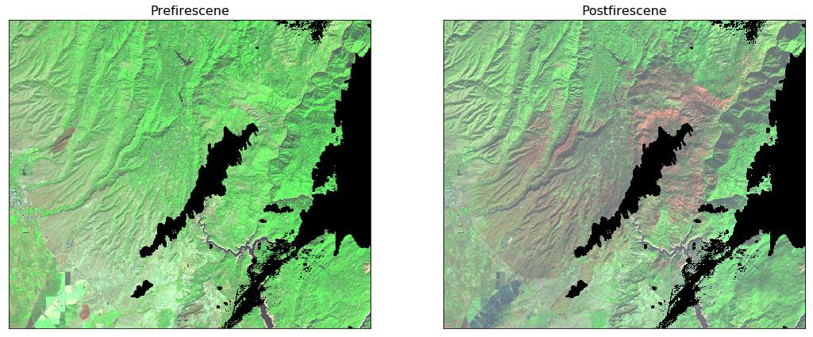

```python
img754 = color_stretch(img, [19, 17, 16], (0, 12000))
img754_pre = color_stretch(img, [6, 4, 3], (0, 16000))

#True color composite
plt.figure(figsize=(18,12))
plt.subplot(121)
plt.imshow(img754_pre)
plt.xticks([])
plt.yticks([])
plt.title("Prefirescene", fontsize=16)
plt.subplot(122)
plt.imshow(img754)
plt.xticks([])
plt.yticks([])
plt.title("Postfirescene", fontsize=16)
plt.show()
plt.savefig(path_output_fin+"Pre_Post_Falsecolor.png",dpi=300)
```

Information on reference dataset and pixels per class.

```python
print_class_count(roi)
```

```
There are 6454 training pixel
Number of pixel per class:
Class 1: 690
Class 2: 775
Class 3: 217
Class 4: 907
Class 5: 785
Class 6: 1464
Class 7: 198
Class 8: 1418
```

### Preparation of variables for classification

Reshapen of img array to X (layerstack with two dimensions: reflectance values of all pixels at classified pixels, for each layer) and y (referencedata, one dimension: all classified pixels)

```python
X = img[roi > 0, :]
y = roi[roi > 0]

print "Shpae of X array (layerstack): {sz}".format(sz=X.shape)
print "Shape of y array (reference data): {sz}".format(sz=y.shape)
```

```
Shpae of X array (layerstack): (6454, 26)
Shape of y array (reference data): (6454,)
```

#### Splitting reference data in training (60%) and testing dataset (40%)

random state = 1 --> same random selection (ensures reproductivity of results)  
default: shuffle = True --> data is shuffled before splitting

```python
X_train, X_test, y_train, y_test = train_test_split(X, y, test_size=0.4, train_size=0.6,
                        random_state=1,stratify=y)
#shapes of splittet datasets
print "Splitting of reference data in training and testing dataset (60:40):"
print "Training dataset (Shape): X: {x}, y:{y}".format(x=X_train.shape, y=y_train.shape)
print "Testing dataset (Shape): X: {x}, y:{y}".format(x=X_test.shape,y=y_test.shape)
```

```
Splitting of reference data in training and testing dataset (60:40):
Training dataset (Shape): X: (3872, 26), y:(3872,)
Testing dataset (Shape): X: (2582, 26), y:(2582,)
```

#### Resampling of training dataset

Balancing the number of pixels per class by under- or oversampling them to the median of all classes.  
**Note:** this approach (first undersampling, then synthetically oversampling) could be questioned and should rather be tested step by step (quality assessment). However, for this case, it was carried out to exemplify how to balance the classes to ensure that also classes with a smaller number of pixels can be properly predicted.

```python
#joining the training datasat (X_train and y_train) in one array
df_train = np.column_stack((X_train, y_train))
print "\nShape of training dataset: {l} (=number of pixel)".format(l=len(df_train))
#print information of total number and number of pixels per class in training dataset
print_class_count(df_train[:,26][df_train[:,26] > 0]) #df_train[:,26] contains the classified pixels
```

```
Shape of training dataset: 3872 (=number of pixel)
There are 3872 training pixel
Number of pixel per class:
Class 1: 414
Class 2: 465
Class 3: 130
Class 4: 544
Class 5: 471
Class 6: 878
Class 7: 119
Class 8: 851
```

Balancing the unequal distribution within the training dataset. Median as sampling strategy.

```python
list_counts = get_class_count_list(df_train[:,26][df_train[:,26] > 0]) #get_class_clount_list creats list with number of pixel per class
array_counts = np.asarray(list_counts)
counts_median = int(np.median(array_counts))

#undersampling
rus = RandomUnderSampler(random_state=3, sampling_strategy={4:counts_median, 5:counts_median, 6:counts_median, 8:counts_median})
#sampling_strategy --> classes greater than median (selected manually)
X_rus, y_rus = rus.fit_resample(X_train, y_train)

#oversampling with SMOTE
smote = SMOTE(random_state=3, sampling_strategy={1:counts_median, 2:counts_median, 3:counts_median, 7:counts_median})
X_resampled, y_resampled = smote.fit_resample(X_rus, y_rus)
#print information of number and distribution of pixels
print_class_count(y_resampled)
```

```
There are 3744 training pixel
Number of pixel per class:
Class 1: 468
Class 2: 468
Class 3: 468
Class 4: 468
Class 5: 468
Class 6: 468
Class 7: 468
Class 8: 468
```

## Start Random Forest Classification

Building the decision trees (amount=500).

```python
rf = RandomForestClassifier(n_estimators=500, oob_score=True)
#Fitting model to training dataset
rf = rf.fit(X_resampled, y_resampled)
#rf = rf.fit(X, y) #without split in training and testing dataset
#rf = rf.fit(X_train, y_train) #with split but without resampling of classes
```

Preparation of prediction (=classification) of the raster scene: Reshaping of img array in two dimensions (nrow * ncol, nband)

```python
new_shape = (img.shape[0] * img.shape[1], img.shape[2])

img_as_array = img[:, :, :].reshape(new_shape)
print "Reshaping of X Arrays in two dimensions: {o} -> {n}".format(o=img.shape,
                                          n=img_as_array.shape)
```

```
Reshaping of X Arrays in two dimensions: (1149, 1346, 26) -> (1546554, 26)
```

Classification of each pixel and reshaping in original raster shape (nrow, ncol).

```python
class_prediction = rf.predict(img_as_array)
class_prediction = class_prediction.reshape(img[:, :, 0].shape)
print "Shape of final classification: {o}". format(o=class_prediction.shape)
```

```
Shape of final classification: (1149, 1346)
```

### Analysis of the classification

```python
print "The OOB score for accuracy is: {oob}%".format(oob=rf.oob_score_ * 100)
print "Evaluation of the significance of each band for the classification"
for b, imp in zip(name_list, rf.feature_importances_):
    print('Band {b} Significance: {imp}'.format(b=b, imp=imp))
```

```
The OOB score for accuracy is: 99.7329059829%
Evaluation of the significance of each band for the classification
Band LC08_Prefire_Paradise_masked_B1 Significance: 0.0428200344383
Band LC08_Prefire_Paradise_masked_B2 Significance: 0.0366345366803
Band LC08_Prefire_Paradise_masked_B3 Significance: 0.0197247810189
Band LC08_Prefire_Paradise_masked_B4 Significance: 0.0255892401103
Band LC08_Prefire_Paradise_masked_B5 Significance: 0.0452435059293
Band LC08_Prefire_Paradise_masked_B6 Significance: 0.0393786046902
Band LC08_Prefire_Paradise_masked_B7 Significance: 0.025092208305
Band LC08_Prefire_Paradise_masked_B8 Significance: 0.0178852896469
Band LC08_Prefire_Paradise_masked_B9 Significance: 0.00749764792844
Band LC08_Prefire_Paradise_masked_B10 Significance: 0.0162088774538
Band LC08_Prefire_Paradise_masked_B11 Significance: 0.0130162254877
Band LC08_Prefire_Paradise_masked_NBR Significance: 0.0205244504475
Band LC08_Prefire_Paradise_masked_NDVI Significance: 0.10062077765
Band LC08_Postfire_Paradise_masked_B1 Significance: 0.0536864868782
Band LC08_Postfire_Paradise_masked_B2 Significance: 0.0430851627914
Band LC08_Postfire_Paradise_masked_B3 Significance: 0.0592722331081
Band LC08_Postfire_Paradise_masked_B4 Significance: 0.0332663752171
Band LC08_Postfire_Paradise_masked_B5 Significance: 0.0668938805704
Band LC08_Postfire_Paradise_masked_B6 Significance: 0.0385923501541
Band LC08_Postfire_Paradise_masked_B7 Significance: 0.0469065278778
Band LC08_Postfire_Paradise_masked_B8 Significance: 0.0354676200896
Band LC08_Postfire_Paradise_masked_B9 Significance: 0.00953172908766
Band LC08_Postfire_Paradise_masked_B10 Significance: 0.0247853691955
Band LC08_Postfire_Paradise_masked_B11 Significance: 0.0180894116114
Band LC08_Postfire_Paradise_masked_NBR Significance: 0.0666222938827
Band LC08_Postfire_Paradise_masked_NDVI Significance: 0.0935643797499
```

As we can see, the indices (NDVI and NBR) - explicitely compiled for a better data basis - explain a great share of the classification. Also, Band 5 (NIR) has a high explanatory importance which does not surprise, as its values indicate the reflectance of vegetation, which - in different state - dominates the satellite scene.

#### Accuracy Assessment

```python
#Classification with testing dataset (X_test, y_test)
y_TestPredicted = rf.predict(X_test)
#Result accuracy assessment
print "Accuracy score:", accuracy_score(y_test,y_TestPredicted)
print "Confusion matrix:\n", confusion_matrix(y_test,y_TestPredicted)
print "Classification report:\n", classification_report(y_test,y_TestPredicted)
```

```
Accuracy score: 0.9957397366382649
Confusion matrix:
[[275   0   0   0   0   0   1   0]
 [  0 310   0   0   0   0   0   0]
 [  0   0  86   1   0   0   0   0]
 [  0   0   0 363   0   0   0   0]
 [  0   0   0   0 312   2   0   0]
 [  0   0   0   0   2 584   0   0]
 [  4   0   0   0   0   1  74   0]
 [  0   0   0   0   0   0   0 567]]
Classification report:
              precision    recall  f1-score   support

         1.0       0.99      1.00      0.99       276
         2.0       1.00      1.00      1.00       310
         3.0       1.00      0.99      0.99        87
         4.0       1.00      1.00      1.00       363
         5.0       0.99      0.99      0.99       314
         6.0       0.99      1.00      1.00       586
         7.0       0.99      0.94      0.96        79
         8.0       1.00      1.00      1.00       567

   micro avg       1.00      1.00      1.00      2582
   macro avg       0.99      0.99      0.99      2582
weighted avg       1.00      1.00      1.00      2582
```

With an accuracy score of 99.6%, it is very likely, that the Random Forest classifier has overfittet the model. Different parameters should be tested (e.g. with [GridSearchCV](https://scikit-learn.org/stable/modules/generated/sklearn.model_selection.GridSearchCV.html)) and classifiers (such as SVM) be applied.

## Part III: Postprocessing

#### Reduction of the Salt-and-Pepper-Effect

The Salt-and-Pepper-Effect results from the pixel based classification, which can be reduced by applying a filter, such as a modal filter in a 3x3 moving window. This filter assigns the most frequent, surrounding pixel value to the central pixel. The respective function had to be defined (see "Function Definitions"). The smoothing effect of the filter highlights trends of the pixel based classification, which is why the certain loss of information can be accepted.

```python
class_prediction_filtered = generic_filter(class_prediction,function=modal_filter,size=3)
```

### Visualization with matplotlib

For labeling and assigning colors to the classes a dictionary is set up and then translated into the necessary lists. This allows to change labels and color assignments more quickly.

```python
classes = {
    1 : ("Bare Area", "#964b00"),
    2 : ("Masked Cloud","#ffffff"),
    3 : ("Water", "#1f78b4"),
    4 : ("Shadow (Terrain)", "#000000"),
    5 : ("Vegetation", "#33a02c"),
    6 : ("Agricultural Area", "#b2df8a"),
    7 : ("Sealed Area", "#edb60e"),
    8 : ("Burned Area","#e44dcc")}

classes_colors = []
classes_labels = []

for key in classes:
    values = classes.get(key)
    label = values[0]
    color = values[1]

    classes_labels.append(label)
    classes_colors.append(color)

n_classes = class_prediction.max()
```

### Comparison of classification without and with applied modal-filter

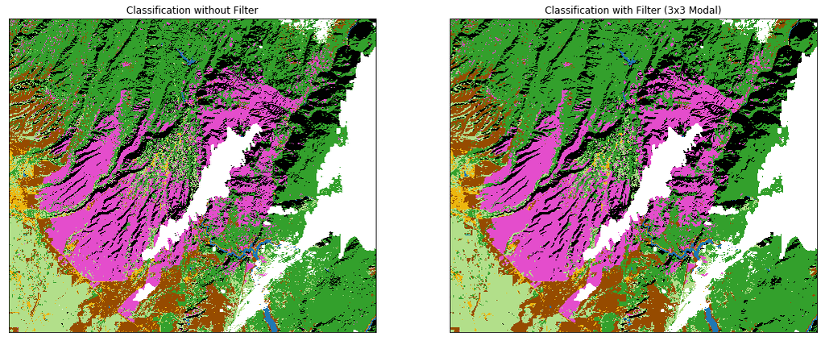

```python
fig = plt.figure(figsize=(18,12))
cmap = plt.matplotlib.colors.ListedColormap(classes_colors, N=n_classes) #colormap
ax1 = fig.add_subplot(121)
ax2 = fig.add_subplot(122)
ax1.set_xticks([])
ax1.set_yticks([])
ax2.set_xticks([])
ax2.set_yticks([])
ax1.imshow(class_prediction,cmap=cmap)
ax2.imshow(class_prediction_filtered,cmap=cmap)
ax1.title.set_text("Classification without Filter")
ax2.title.set_text("Classification with Filter (3x3 Modal)")
plt.show()
```

## Final visualization

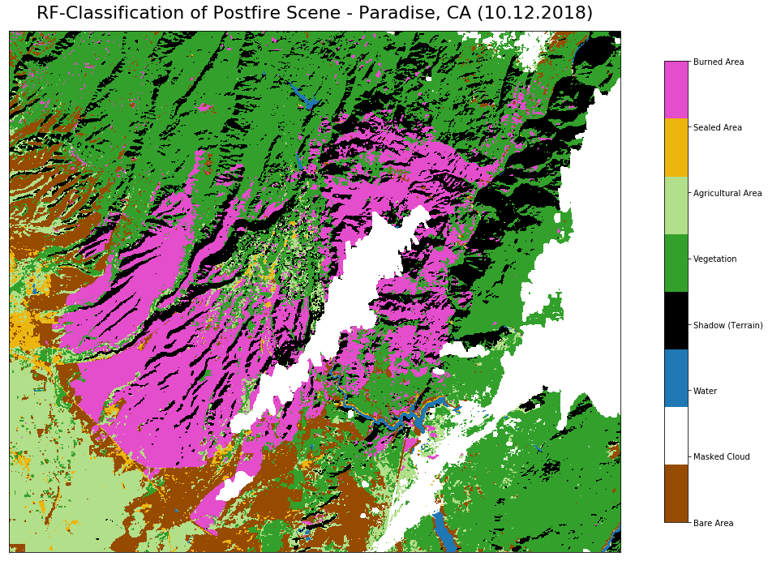

```python
fig, ax = plt.subplots(figsize=(15, 15), subplot_kw={"xticks": [], "yticks": []})
cmap = plt.matplotlib.colors.ListedColormap(classes_colors, N=n_classes) #colormap
cax = ax.imshow(class_prediction_filtered,cmap=cmap)

plt.title("RF-Classification of Postfire Scene - Paradise, CA (10.12.2018)", fontsize=22, pad=15)
cbar = fig.colorbar(cax, ax=ax, fraction=0.034, pad=0.065)
cbar.ax.set_yticklabels(classes_labels)
plt.savefig(path_output_fin+"Classifikation.png",dpi=300)
plt.show()
```

The burned area has been classified very nicely, though the model was very likely overfitting. Still, it is a satisfying result for this first classification.  
**Note:** The shadow class was necessary to establish, as those areas have been classified as "water" in the first run due to their similar spectral reflectance.

#### Save classification as tif-file

```python
filename = "raster_classified_filtered.tif"
filename = path_output_fin + filename
raster_out = write_raster(class_prediction_filtered, GeoTransform, Projection, filename)
```